# Federal Judicial Center Dashboard

[figure not shown]

[figure not shown]

[figure not shown]

[figure not shown]

[figure not shown]

[figure not shown]

# Welcome

Welcome to the Federal Judicial Center Dashboard!

The Federal Judicial Center is the agency within the judicial branch of the U.S. government tasked with examining federal court practices and policies. Among the information it shares with the public is the [Integrated Data Base](https://www.fjc.gov/research/idb), a repository of data on all federal courts.

The database of federal civil court cases between 1988 and the present is available for download as a [tab-delimited file](https://www.fjc.gov/research/idb/civil-cases-filed-terminated-and-pending-sy-1988-present) on the Federal Judicial Center’s website.

This customized dashboard was created on 2020-12-21.

To make your own custom dashboard, visit the [Federal Judicial Center Dashboard project repository on GitHub](https://github.com/DiPierro/federal-judicial-center).

Disclaimers:

- This dashboard is not a product of the Federal Judicial Center.
- This dashboard is a work in progress. Check back for updates and improvements.
- The data presented here have been de-duplicated and cleaned at a basic level, but may still include duplicate cases and other errors. Plaintiff and defendant names have not been standardized.

For questions, comments and bugs, contact dipierro@stanford.edu.

# By context

## Most-common types of lawsuits in California Central

### Most-common types of lawsuits in California Central

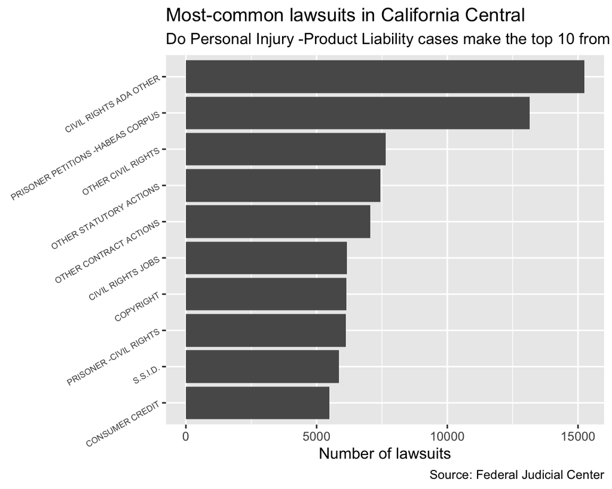

## Most common types of lawsuits in all district courts, 2010 to 2020

### Most common types of lawsuits in all district courts, 2010 to 2020

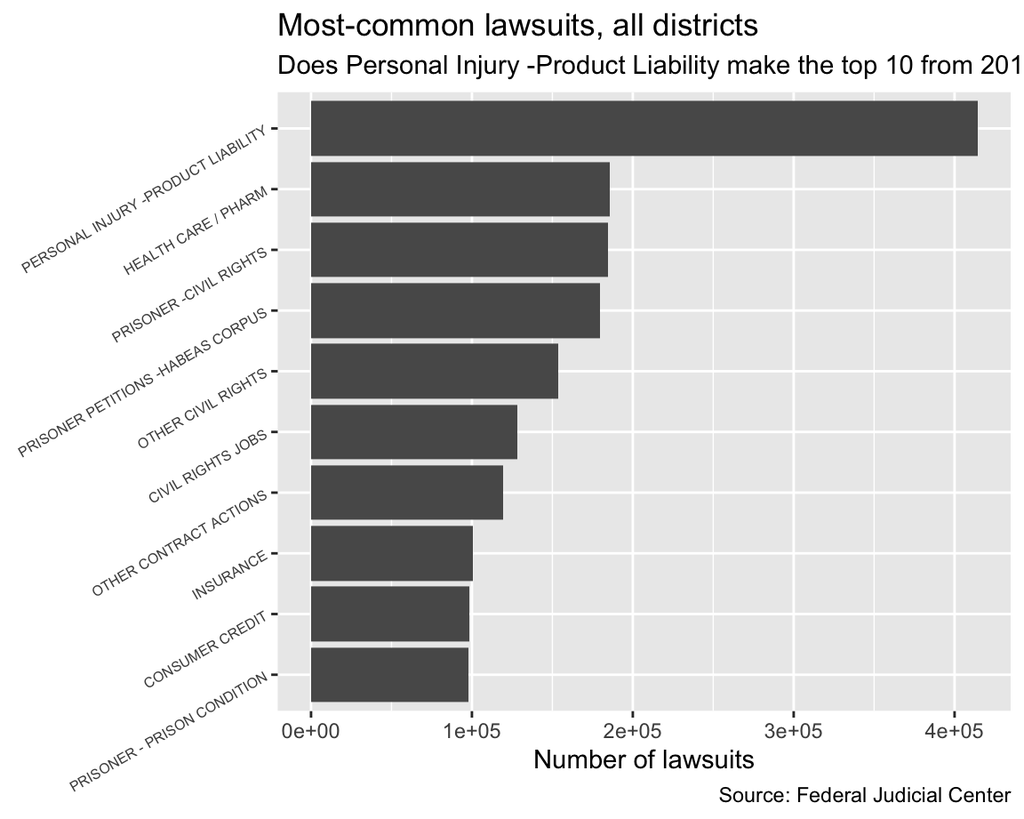

# By year

## Change in all cases types

### Change in all cases types

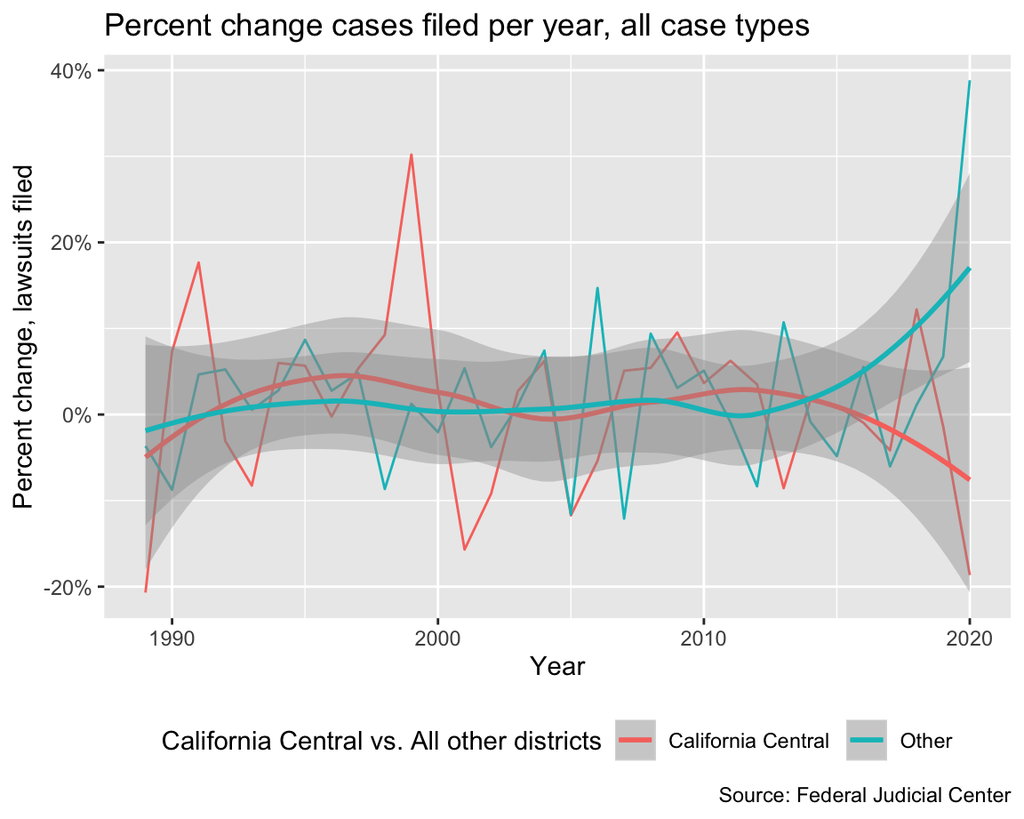

## Change in Personal Injury -Product Liability cases

### Change in Personal Injury -Product Liability cases

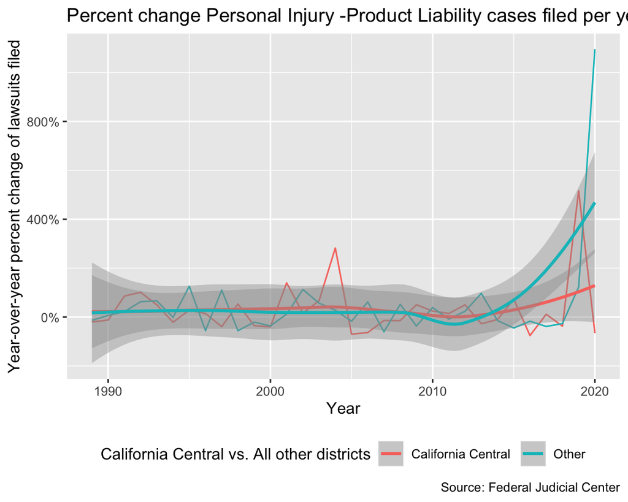

# By district

## How California Central compares on Personal Injury -Product Liability cases, 2010 to 2020

### How California Central compares on Personal Injury -Product Liability cases, 2010 to 2020

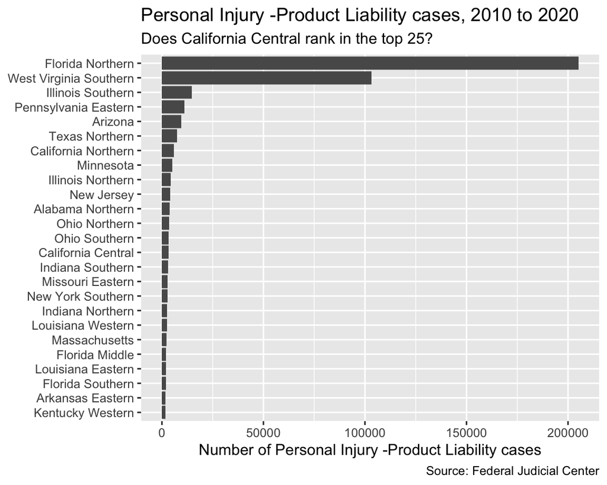

## How California Central compares on Personal Injury -Product Liability cases, 2010 to 2020

### How California Central compares on Personal Injury -Product Liability cases, 2010 to 2020

|  | District | Count |
| --- | --- | --- |
| 1 | Florida Northern | 205151 |
| 2 | West Virginia Southern | 103195 |
| 3 | Illinois Southern | 14746 |
| 4 | Pennsylvania Eastern | 11204 |
| 5 | Arizona | 9590 |
| 6 | Texas Northern | 7393 |
| 7 | California Northern | 6007 |
| 8 | Minnesota | 4986 |
| 9 | Illinois Northern | 4288 |
| 10 | New Jersey | 4113 |

[output cut: 84 more lines]

# By plaintiff and defendant

## Most-common Personal Injury -Product Liability plaintiffs from 2010 to 2020 in the California Central district

### Most-common Personal Injury -Product Liability plaintiffs from 2010 to 2020 in the California Central district

|  | Plaintiff | Count |
| --- | --- | --- |
| 1 | LUKAS | 19 |
| 2 | MARTINEZ | 12 |
| 3 | WILLIAMS | 12 |
| 4 | JONES | 9 |
| 5 | RAMIREZ | 9 |
| 6 | THOMPSON | 9 |
| 7 | BROWN | 8 |
| 8 | JOHNSON, ET AL | 8 |
| 9 | KING | 8 |
| 10 | MOORE, ET AL | 8 |

[output cut: 2513 more lines]

## Most-common Personal Injury -Product Liability defendants from 2010 to 2020 in the California Central district

### Most-common Personal Injury -Product Liability defendants from 2010 to 2020 in the California Central district

|  | Defendant | Count |
| --- | --- | --- |
| 1 | JOHNSON AND JOHNSON, ET AL | 353 |
| 2 | DEPUY ORTHOPAEDICS, INC, ET AL | 300 |
| 3 | BOSTON SCIENTIFIC CORPO, ET AL | 253 |
| 4 | DEPUY ORTHOPAEDICS INC, ET AL | 165 |
| 5 | MCKESSON CORPORATION, ET AL | 102 |
| 6 | TOYOTA MOTOR NORTH AMER, ET AL | 67 |
| 7 | JOHNSON &amp; JOHNSON, ET AL | 62 |
| 8 | NOVARTIS PHARMACEUTICALS CORPO | 57 |
| 9 | NUTRIBULLET, L.L.C., ET AL | 47 |
| 10 | AMERICAN MEDICAL SYSTEM, ET AL | 45 |

[output cut: 728 more lines]

# By county

### Top five counties in California for Personal Injury -Product Liability litigation

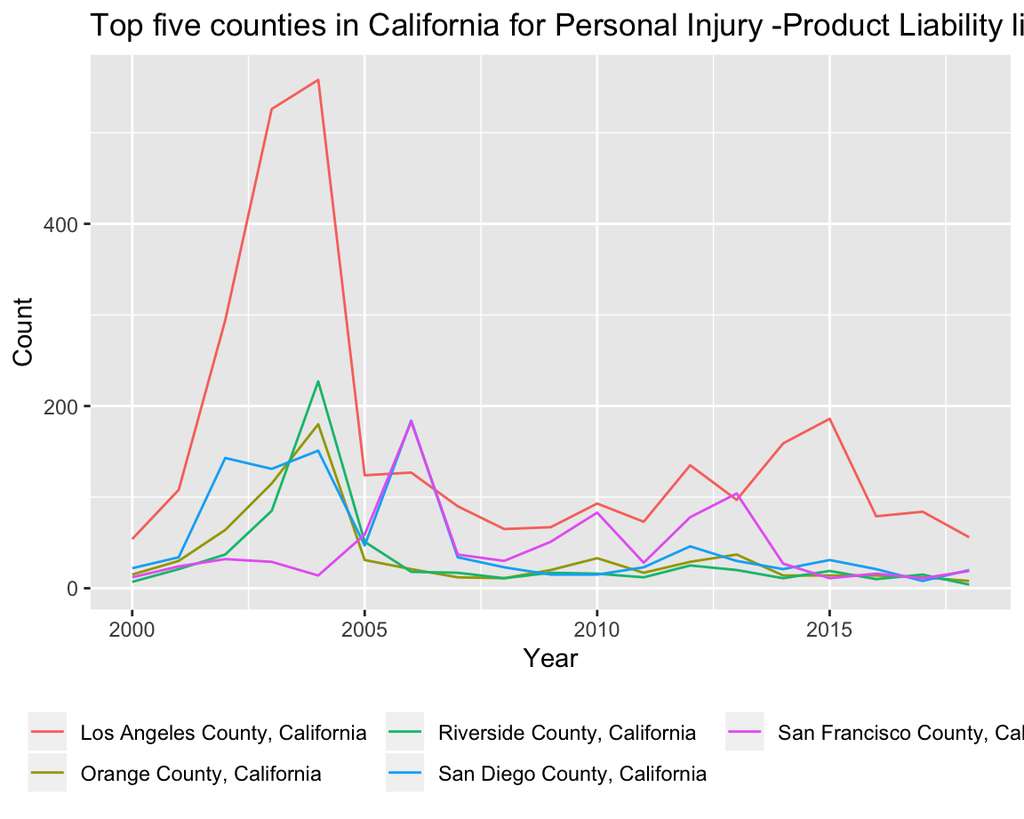

## Number of Personal Injury -Product Liability lawsuits per 1,000 people in California by county

### Number of Personal Injury -Product Liability lawsuits per 1,000 people in California by county

|  | Lawsuits per 1,000 people | County |
| --- | --- | --- |
| 1 | 10.7960191158147 | Sierra |
| 2 | 1.05842121747383 | San Francisco |
| 3 | 0.672315988514602 | Mariposa |
| 4 | 0.445693781686956 | Sacramento |
| 5 | 0.424403183023873 | Modoc |
| 6 | 0.382815253563299 | Shasta |
| 7 | 0.3754364928102 | Amador |
| 8 | 0.33378463267031 | San Diego |
| 9 | 0.319874609950672 | Riverside |
| 10 | 0.302489085201216 | Los Angeles |

[output cut: 48 more lines]